# Project: Investigate a Dataset - [TMDb movie data]

- Introduction
- Data Wrangling
- Exploratory Data Analysis
- Conclusions

## Introduction

### Dataset Description

This data set contains information about 10,000 movies collected from The Movie Database (TMDb), including user ratings and revenue.

We try to clean and manipulate Certain columns when we need, like ‘cast’ and ‘genres’ that contain multiple values separated by pipe (|) characters. The final two columns ending with “_adj” show the budget and revenue of the associated movie in terms of 2010 dollars, accounting for inflation over time.

### Question(s) for Analysis

We will respond and try to found answers for this 2 questions : Which genres are most popular from year to year? What kinds of properties are associated with movies that have high revenue?

```python
# Use this cell to set up import statements for all of the packages that you
#   plan to use.
import numpy as np
import pandas as pd
import matplotlib.pyplot as plt
import seaborn as sns
# Remember to include a 'magic word' so that your visualizations are plotted
#   inline with the notebook. See this page for more:
#   http://ipython.readthedocs.io/en/stable/interactive/magics.html
```

```python
# Upgrade pandas to use dataframe.explode() function.
!pip install --upgrade pandas==0.25.0
```

## Data Wrangling

### General Properties

```python
# Load your data and print out a few lines. Perform operations to inspect data
#   types and look for instances of missing or possibly errant data.
df=pd.read_csv('tmdb-movies.csv')
df.head()
```

|  | id | imdb_id | popularity | budget | revenue | original_title | cast | homepage | director | tagline | ... | overview | runtime | genres | production_companies | release_date | vote_count | vote_average | release_year | budget_adj | revenue_adj |
| --- | --- | --- | --- | --- | --- | --- | --- | --- | --- | --- | --- | --- | --- | --- | --- | --- | --- | --- | --- | --- | --- |
| 0 | 135397 | tt0369610 | 32.985763 | 150000000 | 1513528810 | Jurassic World | Chris Pratt\|Bryce Dallas Howard\|Irrfan Khan\|Vi... | http://www.jurassicworld.com/ | Colin Trevorrow | The park is open. | ... | Twenty-two years after the events of Jurassic ... | 124 | Action\|Adventure\|Science Fiction\|Thriller | Universal Studios\|Amblin Entertainment\|Legenda... | 6/9/15 | 5562 | 6.5 | 2015 | 1.379999e+08 | 1.392446e+09 |
| 1 | 76341 | tt1392190 | 28.419936 | 150000000 | 378436354 | Mad Max: Fury Road | Tom Hardy\|Charlize Theron\|Hugh Keays-Byrne\|Nic... | http://www.madmaxmovie.com/ | George Miller | What a Lovely Day. | ... | An apocalyptic story set in the furthest reach... | 120 | Action\|Adventure\|Science Fiction\|Thriller | Village Roadshow Pictures\|Kennedy Miller Produ... | 5/13/15 | 6185 | 7.1 | 2015 | 1.379999e+08 | 3.481613e+08 |
| 2 | 262500 | tt2908446 | 13.112507 | 110000000 | 295238201 | Insurgent | Shailene Woodley\|Theo James\|Kate Winslet\|Ansel... | http://www.thedivergentseries.movie/#insurgent | Robert Schwentke | One Choice Can Destroy You | ... | Beatrice Prior must confront her inner demons ... | 119 | Adventure\|Science Fiction\|Thriller | Summit Entertainment\|Mandeville Films\|Red Wago... | 3/18/15 | 2480 | 6.3 | 2015 | 1.012000e+08 | 2.716190e+08 |
| 3 | 140607 | tt2488496 | 11.173104 | 200000000 | 2068178225 | Star Wars: The Force Awakens | Harrison Ford\|Mark Hamill\|Carrie Fisher\|Adam D... | http://www.starwars.com/films/star-wars-episod... | J.J. Abrams | Every generation has a story. | ... | Thirty years after defeating the Galactic Empi... | 136 | Action\|Adventure\|Science Fiction\|Fantasy | Lucasfilm\|Truenorth Productions\|Bad Robot | 12/15/15 | 5292 | 7.5 | 2015 | 1.839999e+08 | 1.902723e+09 |
| 4 | 168259 | tt2820852 | 9.335014 | 190000000 | 1506249360 | Furious 7 | Vin Diesel\|Paul Walker\|Jason Statham\|Michelle ... | http://www.furious7.com/ | James Wan | Vengeance Hits Home | ... | Deckard Shaw seeks revenge against Dominic Tor... | 137 | Action\|Crime\|Thriller | Universal Pictures\|Original Film\|Media Rights ... | 4/1/15 | 2947 | 7.3 | 2015 | 1.747999e+08 | 1.385749e+09 |

5 rows × 21 columns

```python
df.info()
```

```
<class 'pandas.core.frame.DataFrame'>
RangeIndex: 10866 entries, 0 to 10865
Data columns (total 21 columns):
 #   Column                Non-Null Count  Dtype
---  ------                --------------  -----
 0   id                    10866 non-null  int64
 1   imdb_id               10856 non-null  object
 2   popularity            10866 non-null  float64
 3   budget                10866 non-null  int64
 4   revenue               10866 non-null  int64
 5   original_title        10866 non-null  object
 6   cast                  10790 non-null  object
 7   homepage              2936 non-null   object
 8   director              10822 non-null  object
 9   tagline               8042 non-null   object
 10  keywords              9373 non-null   object
 11  overview              10862 non-null  object
 12  runtime               10866 non-null  int64
 13  genres                10843 non-null  object
 14  production_companies  9836 non-null   object
 15  release_date          10866 non-null  object
 16  vote_count            10866 non-null  int64
 17  vote_average          10866 non-null  float64
 18  release_year          10866 non-null  int64
 19  budget_adj            10866 non-null  float64
 20  revenue_adj           10866 non-null  float64
dtypes: float64(4), int64(6), object(11)
memory usage: 1.7+ MB
```

```python
df.nunique()
```

```
id                      10865
imdb_id                 10855
popularity              10814
budget                    557
revenue                  4702
original_title          10571
cast                    10719
homepage                 2896
director                 5067
tagline                  7997
keywords                 8804
overview                10847
runtime                   247
genres                   2039
production_companies     7445
release_date             5909
vote_count               1289
vote_average               72
release_year               56
budget_adj               2614
revenue_adj              4840
dtype: int64
```

```python
df.info()
```

```
<class 'pandas.core.frame.DataFrame'>
RangeIndex: 10866 entries, 0 to 10865
Data columns (total 21 columns):
 #   Column                Non-Null Count  Dtype
---  ------                --------------  -----
 0   id                    10866 non-null  int64
 1   imdb_id               10856 non-null  object
 2   popularity            10866 non-null  float64
 3   budget                10866 non-null  int64
 4   revenue               10866 non-null  int64
 5   original_title        10866 non-null  object
 6   cast                  10790 non-null  object
 7   homepage              2936 non-null   object
 8   director              10822 non-null  object
 9   tagline               8042 non-null   object
 10  keywords              9373 non-null   object
 11  overview              10862 non-null  object
 12  runtime               10866 non-null  int64
 13  genres                10843 non-null  object
 14  production_companies  9836 non-null   object
 15  release_date          10866 non-null  object
 16  vote_count            10866 non-null  int64
 17  vote_average          10866 non-null  float64
 18  release_year          10866 non-null  int64
 19  budget_adj            10866 non-null  float64
 20  revenue_adj           10866 non-null  float64
dtypes: float64(4), int64(6), object(11)
memory usage: 1.7+ MB
```

```python
df.dtypes
```

```
id                        int64
imdb_id                  object
popularity              float64
budget                    int64
revenue                   int64
original_title           object
cast                     object
homepage                 object
director                 object
tagline                  object
keywords                 object
overview                 object
runtime                   int64
genres                   object
production_companies     object
release_date             object
vote_count                int64
vote_average            float64
release_year              int64
budget_adj              float64
revenue_adj             float64
dtype: object
```

### Data Cleaning

We remove Columns 'id' , 'imdb_id', 'homepage' beacause it's not necessary for our analysis

```python
# After discussing the structure of the data and any problems that need to be
#   cleaned, perform those cleaning steps in the second part of this section.
#drop columns that not necessary for our analysis
df.drop(['id' , 'imdb_id', 'homepage'], inplace=True, axis=1)
df.head(1)
```

|  | popularity | budget | revenue | original_title | cast | director | tagline | keywords | overview | runtime | genres | production_companies | release_date | vote_count | vote_average | release_year | budget_adj | revenue_adj |
| --- | --- | --- | --- | --- | --- | --- | --- | --- | --- | --- | --- | --- | --- | --- | --- | --- | --- | --- |
| 0 | 32.985763 | 150000000 | 1513528810 | Jurassic World | Chris Pratt\|Bryce Dallas Howard\|Irrfan Khan\|Vi... | Colin Trevorrow | The park is open. | monster\|dna\|tyrannosaurus rex\|velociraptor\|island | Twenty-two years after the events of Jurassic ... | 124 | Action\|Adventure\|Science Fiction\|Thriller | Universal Studios\|Amblin Entertainment\|Legenda... | 6/9/15 | 5562 | 6.5 | 2015 | 1.379999e+08 | 1.392446e+09 |

```python
#   Convert type of release_date frome object to datetime
df['release_date']= pd.to_datetime(df['release_date'])
df.dtypes
```

[output not shown]

```python
# view missing value count for each feature
df.isnull().sum()
```

[output not shown]

## Exploratory Data Analysis

We must know the more popular genres over the years because this is very important in charting the future of the films that will be produced and increasing the profits

### Research Question 1 (Which genres are most popular from year to year?)

To Answer the question we need just this 3 columns 'genres','popularity' and 'release_year'.

```python
# Use this, and more code cells, to explore your data. Don't forget to add
#   Markdown cells to document your observations and findings.
dfg = df[['genres','popularity','release_year']]
dfg.head()
```

|  | genres | popularity | release_year |
| --- | --- | --- | --- |
| 0 | Action\|Adventure\|Science Fiction\|Thriller | 32.985763 | 2015 |
| 1 | Action\|Adventure\|Science Fiction\|Thriller | 28.419936 | 2015 |
| 2 | Adventure\|Science Fiction\|Thriller | 13.112507 | 2015 |
| 3 | Action\|Adventure\|Science Fiction\|Fantasy | 11.173104 | 2015 |
| 4 | Action\|Crime\|Thriller | 9.335014 | 2015 |

We have for genres multiple values separated by '|' and for that we need to explode them to multiple rows by using function "explode"

```python
dfg["genres"] = dfg["genres"].str.split("|")
dfg = dfg.explode("genres")
```

```python
dfg.head()
```

|  | genres | popularity | release_year |
| --- | --- | --- | --- |
| 0 | Action | 32.985763 | 2015 |
| 0 | Adventure | 32.985763 | 2015 |
| 0 | Science Fiction | 32.985763 | 2015 |
| 0 | Thriller | 32.985763 | 2015 |
| 1 | Action | 28.419936 | 2015 |

Remove Rows that contains null value for column "genres"

```python
dfg.dropna(subset=['genres'],inplace=True)
```

Make sure that we don't have null values for "genres"

```python
print(dfg['genres'].unique())
```

```
['Action' 'Adventure' 'Science Fiction' 'Thriller' 'Fantasy' 'Crime'
 'Western' 'Drama' 'Family' 'Animation' 'Comedy' 'Mystery' 'Romance' 'War'
 'History' 'Music' 'Horror' 'Documentary' 'TV Movie' 'Foreign']
```

```python
dfge_genre_popularity=dfg.groupby(['genres','release_year']).mean()
dfge_genre_popularity.head()
```

| genres | release_year | popularity |
| --- | --- | --- |
| Action | 1960 | 0.590724 |
|  | 1961 | 0.365913 |
|  | 1962 | 0.708945 |
|  | 1963 | 0.951729 |
|  | 1964 | 0.813087 |

we move the index names to columns by using function "reset_index"

```python
dfge_genre_popularity = dfge_genre_popularity.reset_index()
dfge_genre_popularity.head()
```

|  | genres | release_year | popularity |
| --- | --- | --- | --- |
| 0 | Action | 1960 | 0.590724 |
| 1 | Action | 1961 | 0.365913 |
| 2 | Action | 1962 | 0.708945 |
| 3 | Action | 1963 | 0.951729 |
| 4 | Action | 1964 | 0.813087 |

We create a function to draw graph whatever the kind and the size of graph and year value.

```python
def graphpopularity(f,annee,genre,a,b):
    fannee=f[f['release_year']==annee]
    fannee.plot(kind=genre,x = 'genres', xlabel='Genre of movie',ylabel='Popularity',y ='popularity', title='Popularity of any movie genre',figsize=(a,b))
```

# We use Graph Kind Bar because we have a categorical variable.

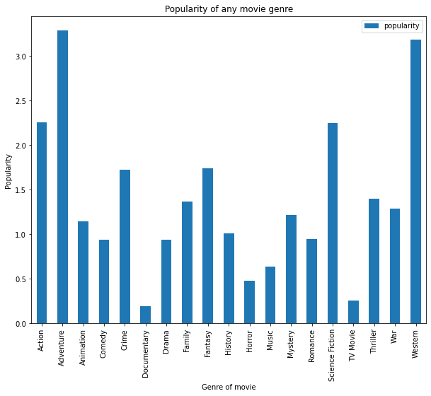

```python
graphpopularity(dfge_genre_popularity,2015,'bar',10,8)
```

The most popular genres on 2015 are : Adventure, Western

The least popular genres on 2015 are : Documentary, TV Movie

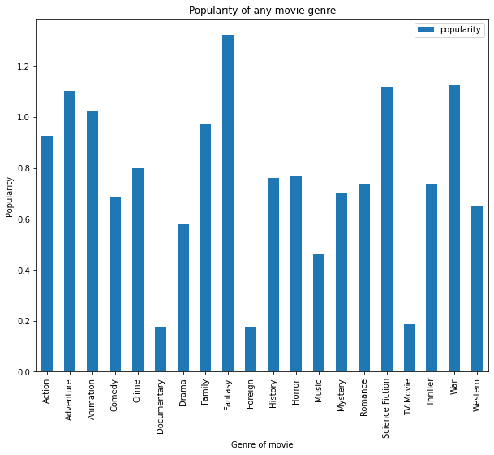

```python
graphpopularity(dfge_genre_popularity,2004,'bar',10,8)
```

The most popular genres on 2004 are : Fantasy, Science Fiction , War

The least popular genres on 2004 are : Documentary, TV Movie, Foreign

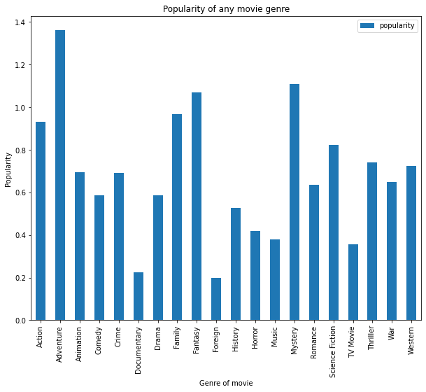

```python
graphpopularity(dfge_genre_popularity,2010,'bar',10,8)
```

The most popular genres on 2010 are : Adventure, Mystery, Fantasy

The least popular genres on 2010 are : Documentary, TV Movie, Foreign

### Research Question 2 (What kinds of properties are associated with movies that have high revenues?)

To study the characteristics of movies that have a high revenue to apply the same things and more in upcoming movies to raise the profit to the max .

```python
# Continue to explore the data to address your additional research
#   questions. Add more headers as needed if you have more questions to
#   investigate.
df['revenue'].describe()
```

```
count    1.086600e+04
mean     3.982332e+07
std      1.170035e+08
min      0.000000e+00
25%      0.000000e+00
50%      0.000000e+00
75%      2.400000e+07
max      2.781506e+09
Name: revenue, dtype: float64
```

We use function describe to see some features of a movie that have high revenue

We see clearly that 75% who gain high revenue is having high popularity and also high budget

```python
high_revenue= df.query('revenue >=1390753000')
high_revenue.describe()
```

|  | popularity | budget | revenue | runtime | vote_count | vote_average | release_year | budget_adj | revenue_adj |
| --- | --- | --- | --- | --- | --- | --- | --- | --- | --- |
| count | 7.000000 | 7.000000e+00 | 7.000000e+00 | 7.000000 | 7.000000 | 7.000000 | 7.000000 | 7.000000e+00 | 7.000000e+00 |
| mean | 11.552080 | 2.110000e+08 | 1.805584e+09 | 148.142857 | 5731.428571 | 7.200000 | 2011.142857 | 2.108461e+08 | 1.821467e+09 |
| std | 9.725483 | 4.066530e+07 | 4.899120e+08 | 23.190721 | 2185.799156 | 0.331662 | 6.644009 | 4.851258e+07 | 6.169491e+08 |
| min | 4.355219 | 1.500000e+08 | 1.405036e+09 | 124.000000 | 2947.000000 | 6.500000 | 1997.000000 | 1.379999e+08 | 1.292632e+09 |
| 25% | 6.791347 | 1.950000e+08 | 1.509889e+09 | 136.500000 | 4479.000000 | 7.200000 | 2010.500000 | 1.793999e+08 | 1.389097e+09 |
| 50% | 9.335014 | 2.000000e+08 | 1.519558e+09 | 141.000000 | 5292.000000 | 7.300000 | 2015.000000 | 2.089437e+08 | 1.443191e+09 |
| 75% | 10.302936 | 2.285000e+08 | 1.956606e+09 | 152.500000 | 7010.000000 | 7.350000 | 2015.000000 | 2.492434e+08 | 2.204564e+09 |
| max | 32.985763 | 2.800000e+08 | 2.781506e+09 | 194.000000 | 8903.000000 | 7.500000 | 2015.000000 | 2.716921e+08 | 2.827124e+09 |

```python
dfs=df[df['revenue']>390753000].iloc[1:80]
dfs.head()
```

[output not shown]

=> We draw scatter graph with parametrs budget and revenue to see the impact of budget on revenue.

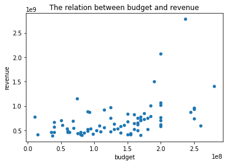

```python
dfs.plot(kind = 'scatter', x = 'budget', y ='revenue',title="The relation between budget and revenue")
```

=> We draw scatter graph with parametrs popularity and revenue to see the impact of popularity on revenue.

[figure not shown]

```python
dfs.plot(kind = 'scatter', x = 'popularity', y ='revenue',title="The relation between budget and revenue")
```

=> We draw scatter graph with parametrs vote average and revenue to see the impact of vote average on revenue.

[figure not shown]

```python
dfs.plot(kind = 'scatter', x = 'vote_average', y ='revenue',title="The relation between budget and revenue")
```

We see clearly that the vote average has a little impact on revenue.

## Conclusions

Results : Our data suggest that

   ```
    - High Budget
    - High Popularity
   ```

Limitaions : There are a couple of limitions on our data :

1. Most of our variables are categorical such as Genres and Cast and Production Companies, which does not allow for a high level of statistical method that can be used to provide correlations etc
2. The statistics used here are descriptive statistics, not inferential, meaning that we did not create any hypotheses or controlled experiments or inferences with our data.
3. We do not have a lot of details for certain factors to draw conclusions.